# Clustering and validation

#### Stability measures: APN (min)

File: meas_12521_1.png

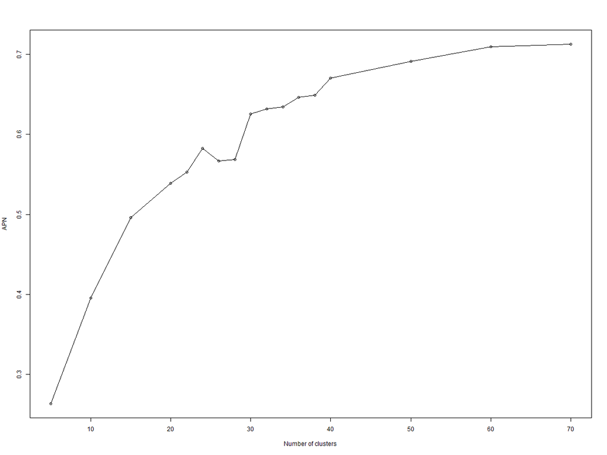

#### Stability measures: AD (min)

File: meas_12521_2.png

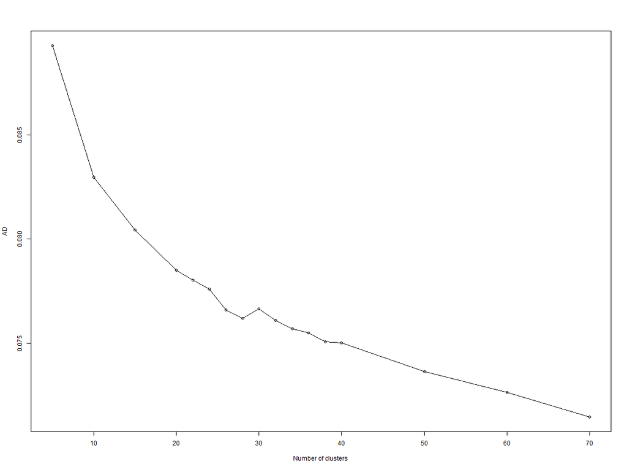

#### Stability measures: ADM (min)

File: meas_12521_3.png

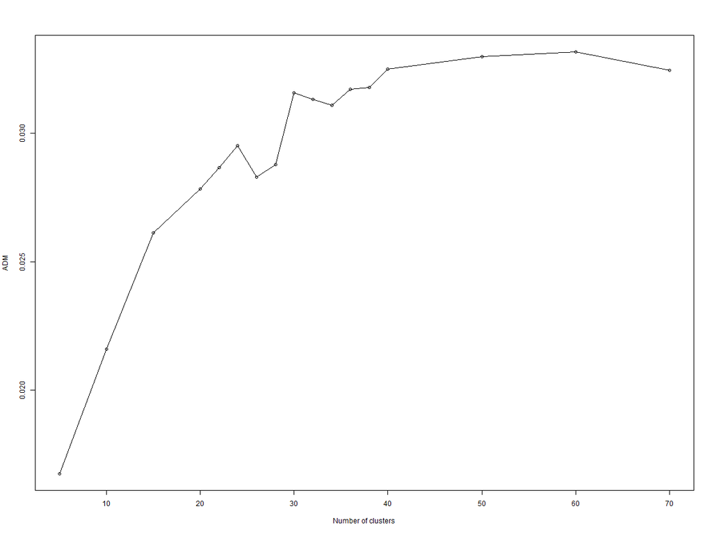

#### Stability measures: FOM (min)

File: meas_12521_4.png

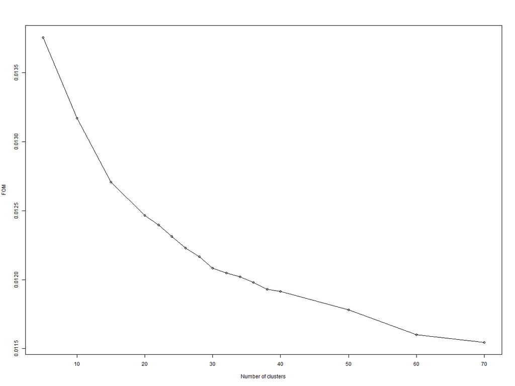

### Clustering: PAM

#### Internal measures: Connectivity (min)

File: meas_12611_1.png

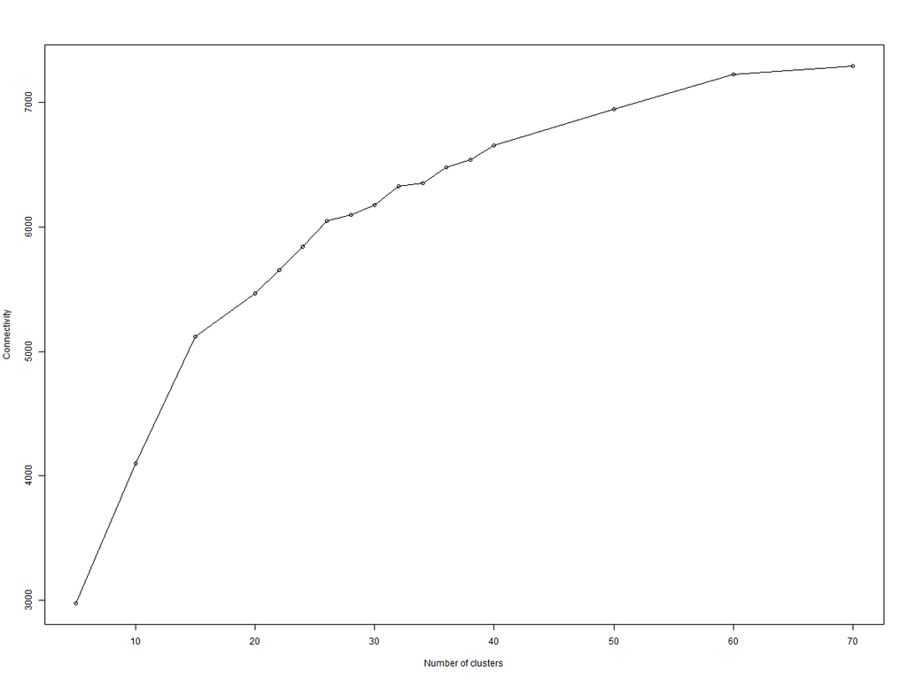

#### Internal measures: Dunn index (max)

File: meas_12611_2.png

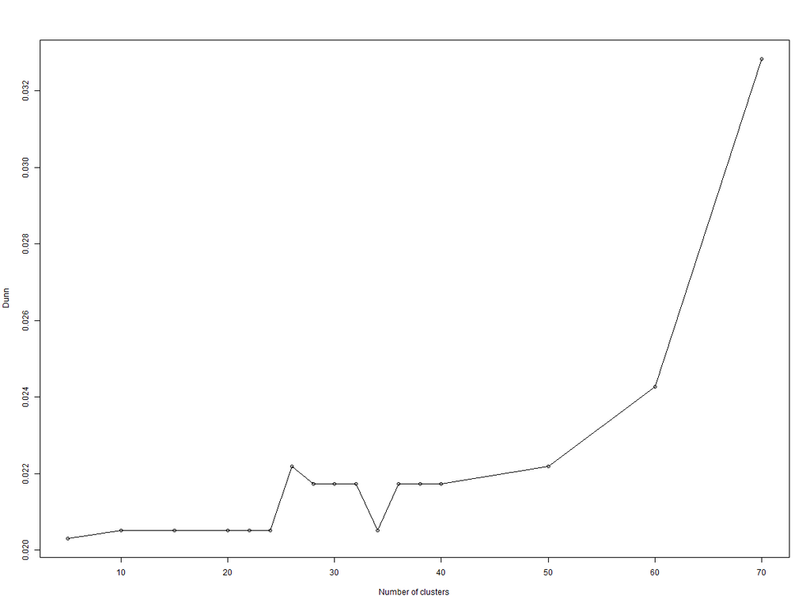

#### Internal measures: Silhouette (max)

File: meas_12611_3.png

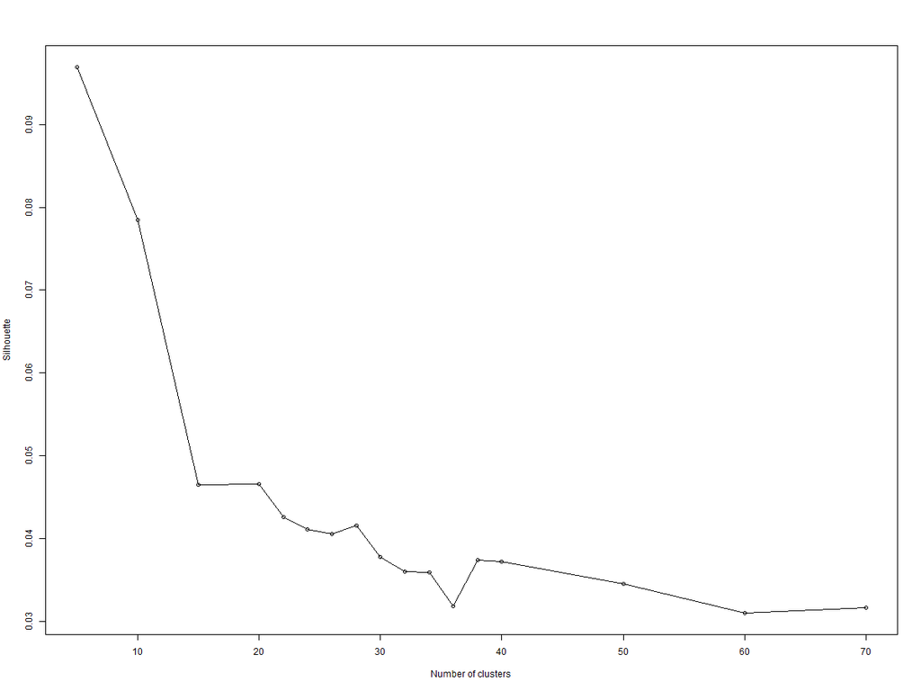

### Clustering: SOTA

#### Internal measures: Connectivity (min)

File: meas_12711_1.png

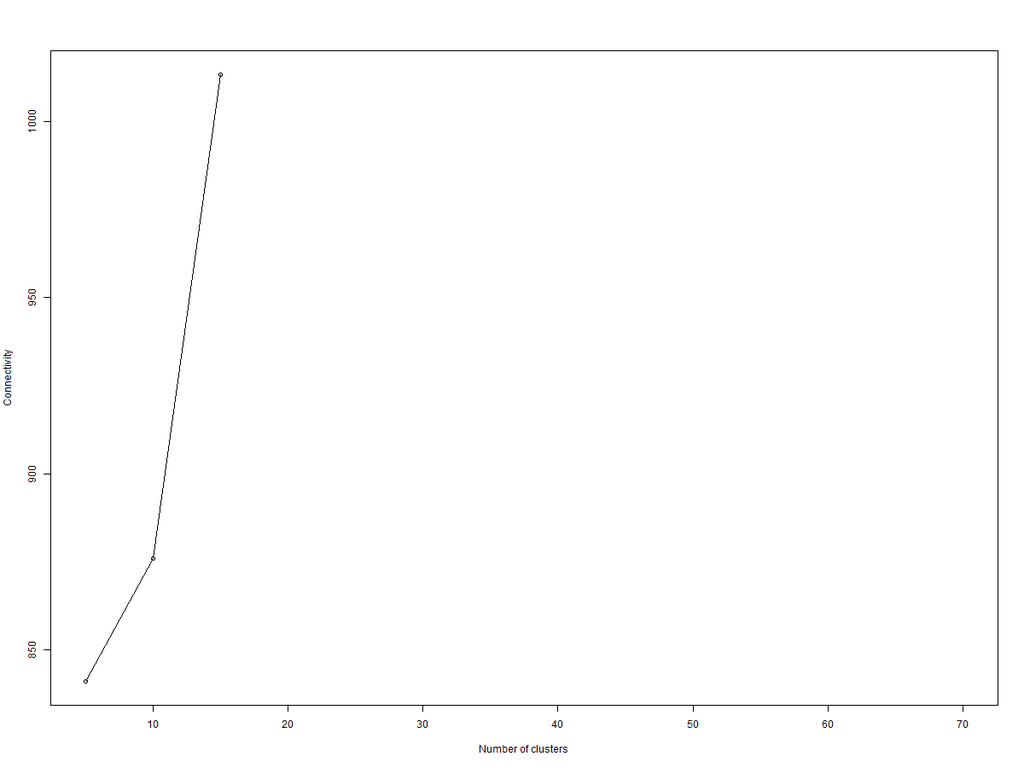

#### Internal measures: Dunn index (max)

File: meas_12711_2.png

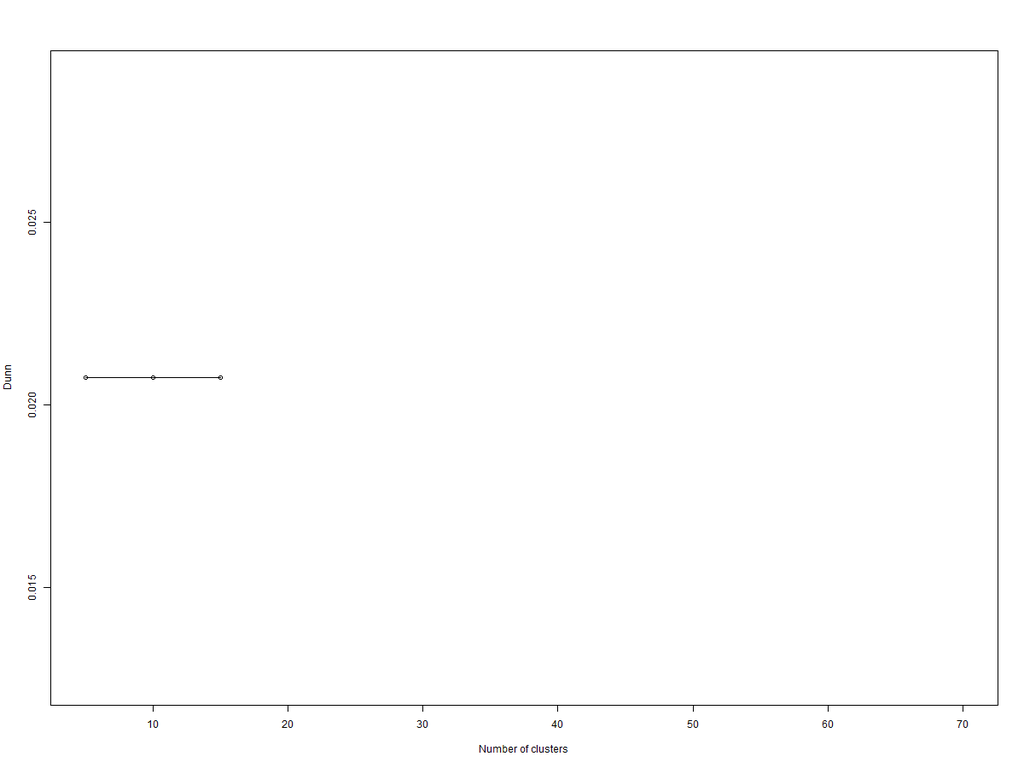

#### Internal measures: Silhouette (max)

File: meas_12711_3.png

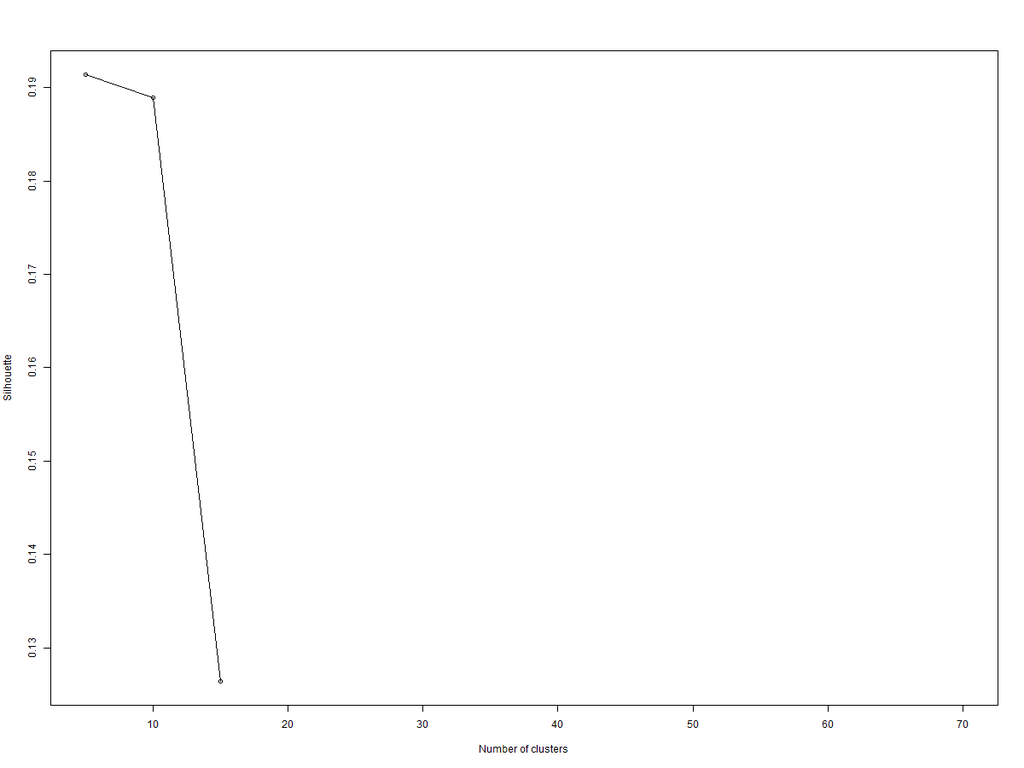

#### Stability measures: APN (min)

File: meas_12721_1.png

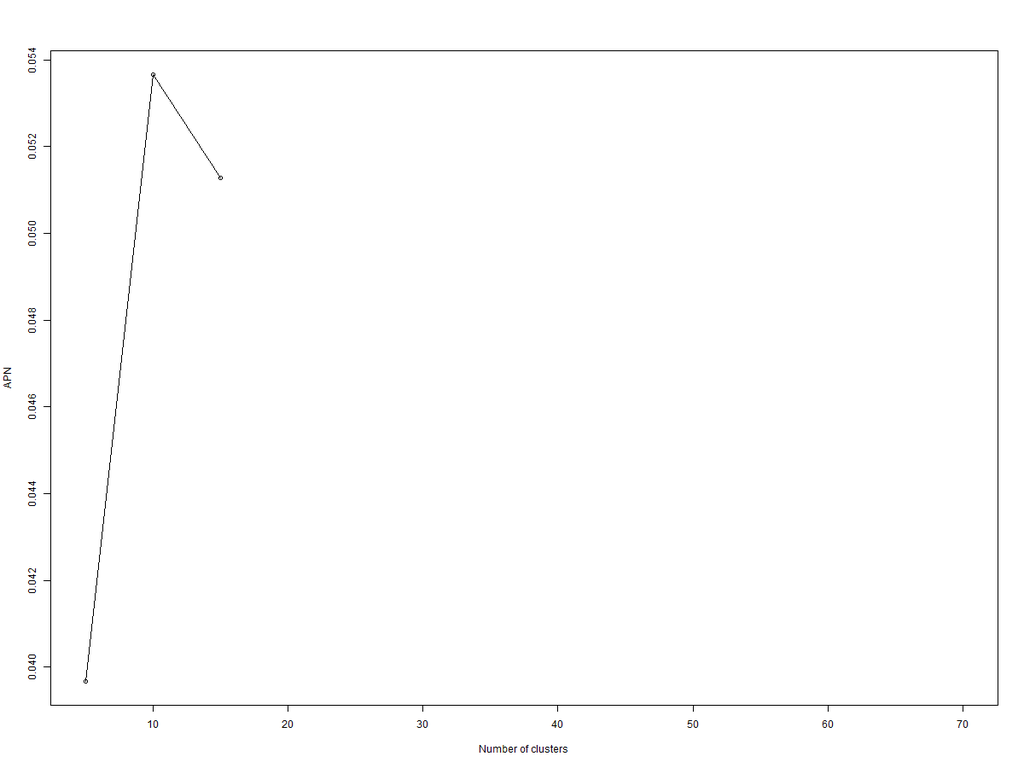

#### Stability measures: AD (min)

File: meas_12721_2.png

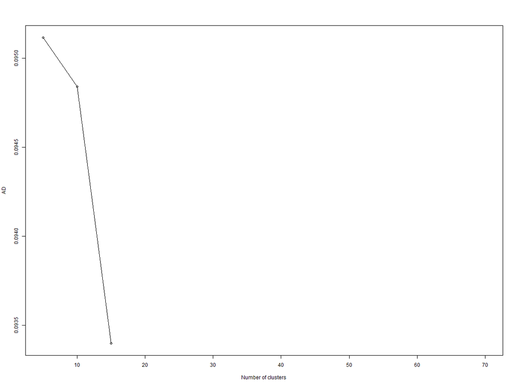

#### Stability measures: ADM (min)

File: meas_12721_3.png

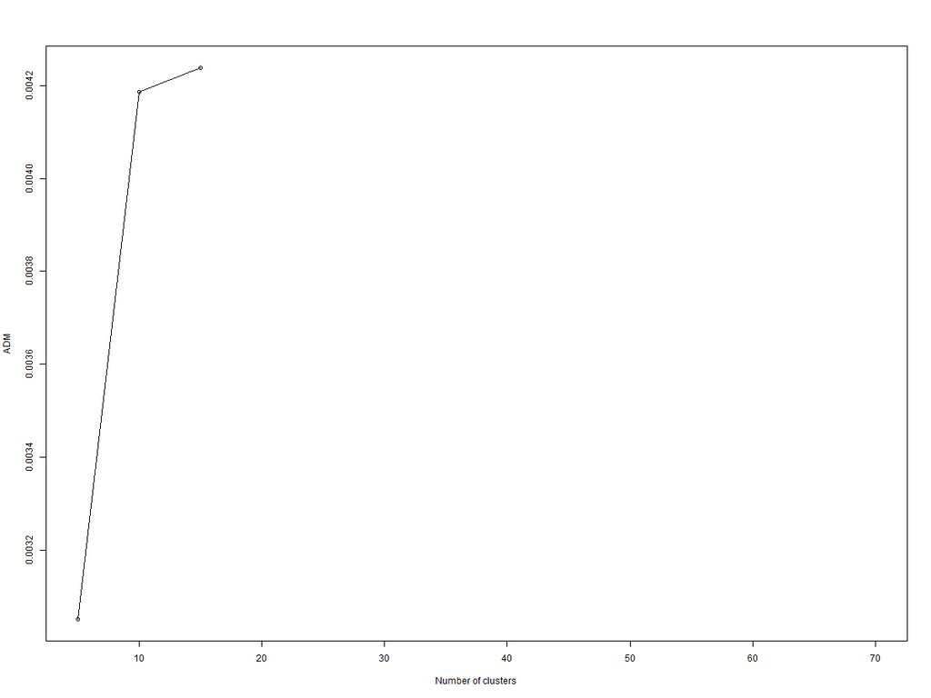

#### Stability measures: FOM (min)

File: meas_12721_4.png

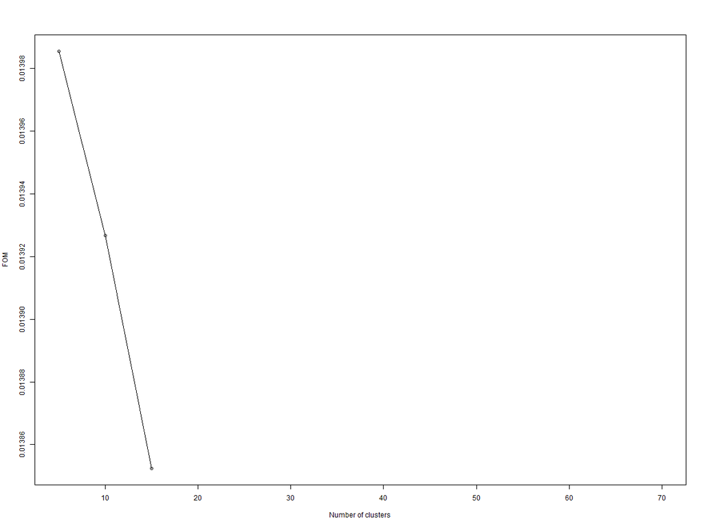

### Clustering: CLARA

#### Internal measures: Connectivity (min)

File: meas_12811_1.png

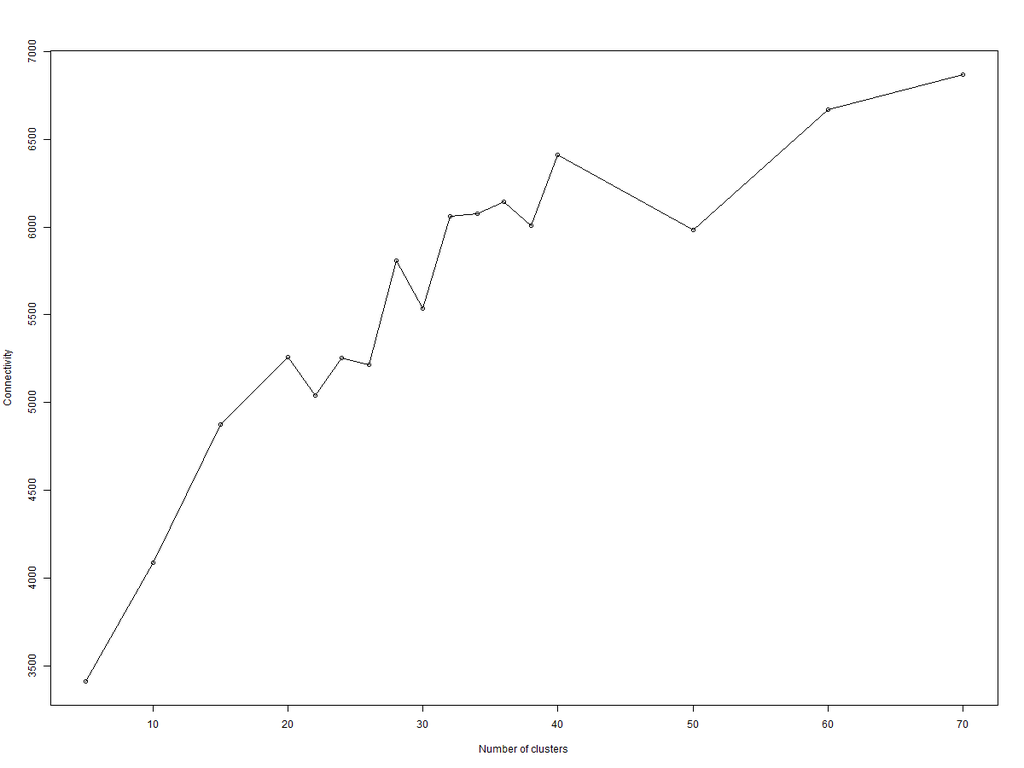

#### Internal measures: Dunn index (max)

File: meas_12811_2.png

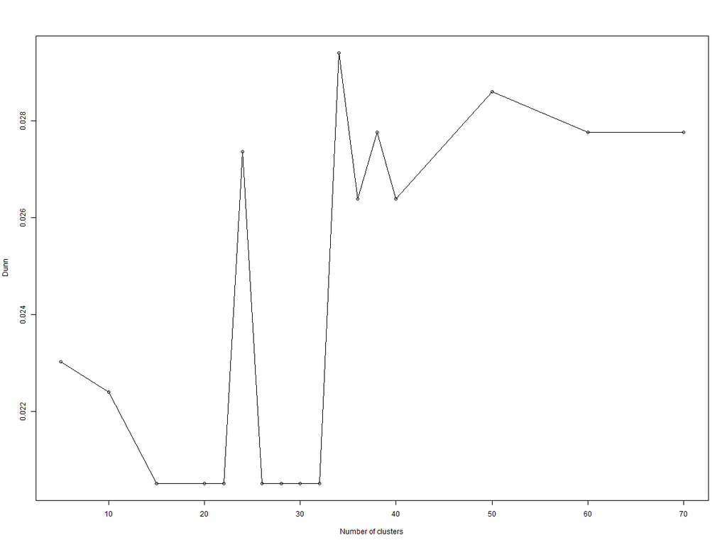

#### Internal measures: Silhouette (max)

File: meas_12811_3.png

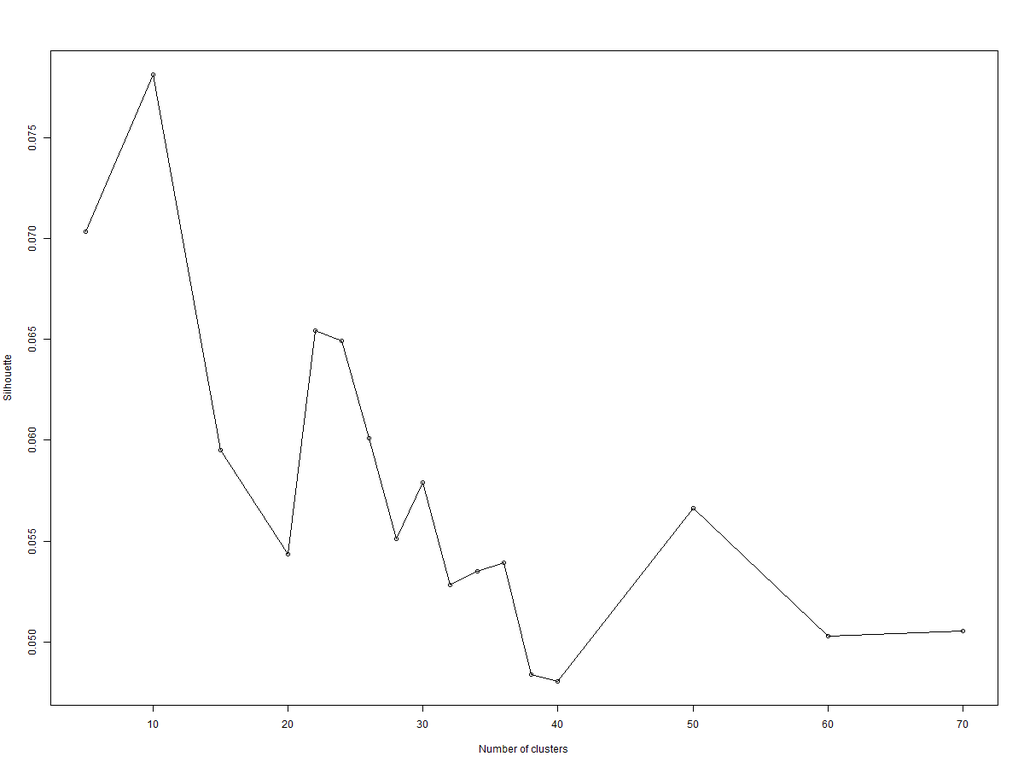

#### Stability measures: APN (min)

File: meas_12821_1.png

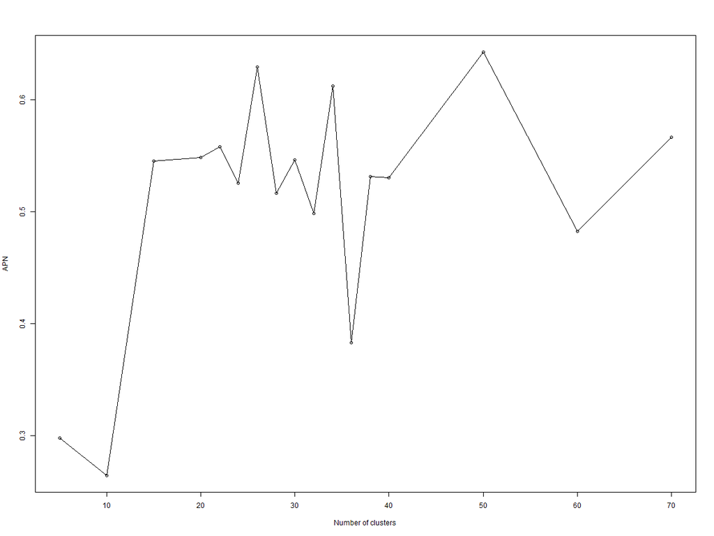

#### Stability measures: AD (min)

File: meas_12821_2.png

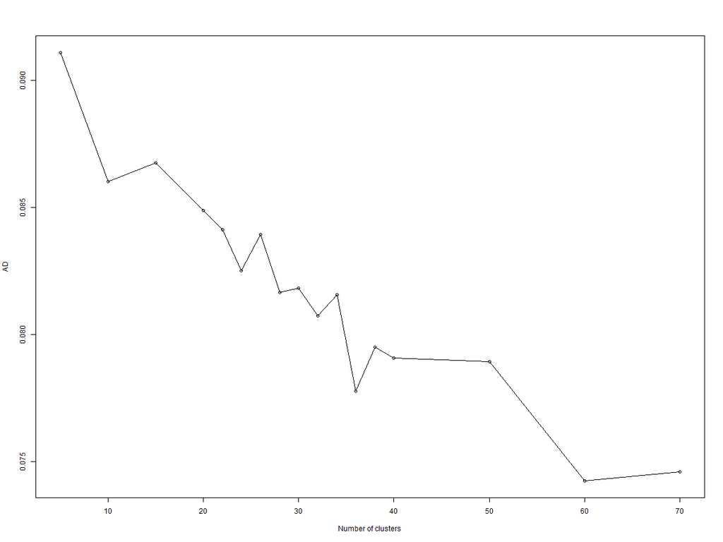

#### Stability measures: ADM (min)

File: meas_12821_3.png

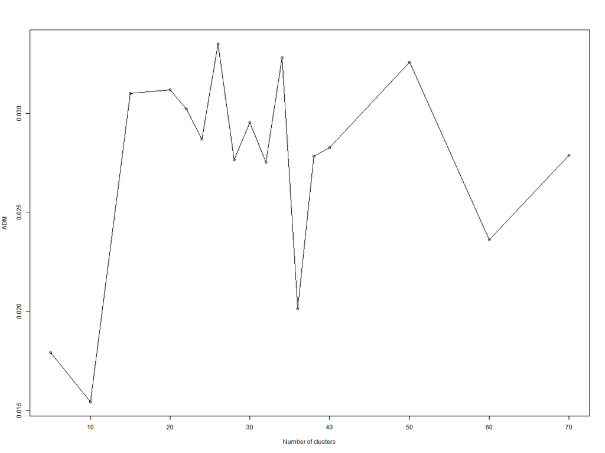

#### Stability measures: FOM (min)

File: meas_12821_4.png

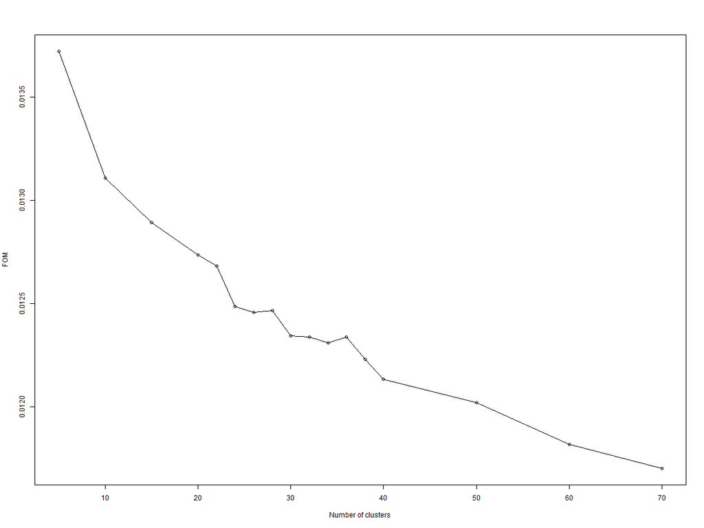

### Clustering: Model-based

#### Internal measures: Connectivity (min)

File: meas_12911_1.png

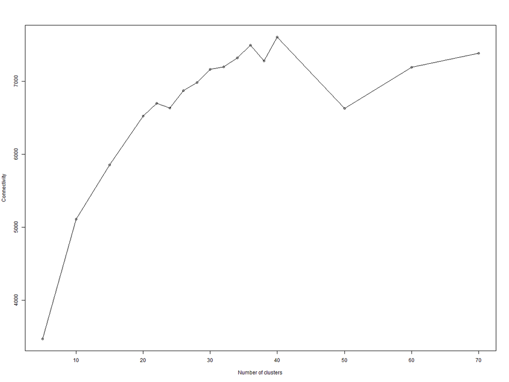

#### Internal measures: Dunn index (max)

File: meas_12911_2.png

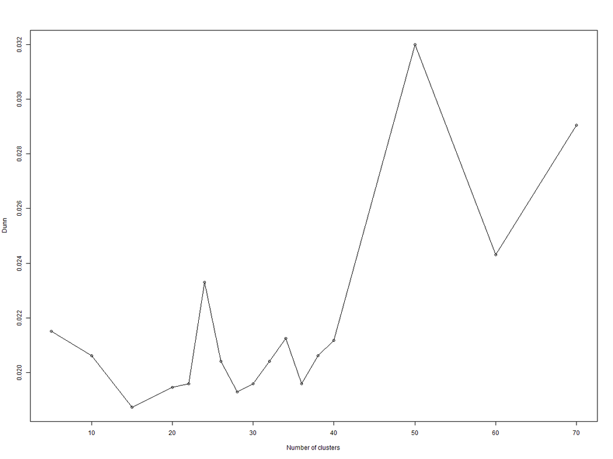

#### Internal measures: Silhouette (max)

File: meas_12911_3.png

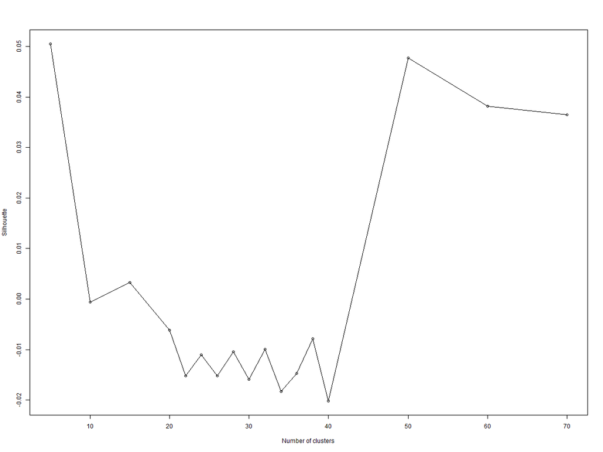

# Dataset: ISSDA

## Set of features: seasonal aggregates

### Clustering: Hierarchical

#### Internal measures: Connectivity (min)

File: meas_13111_1.png

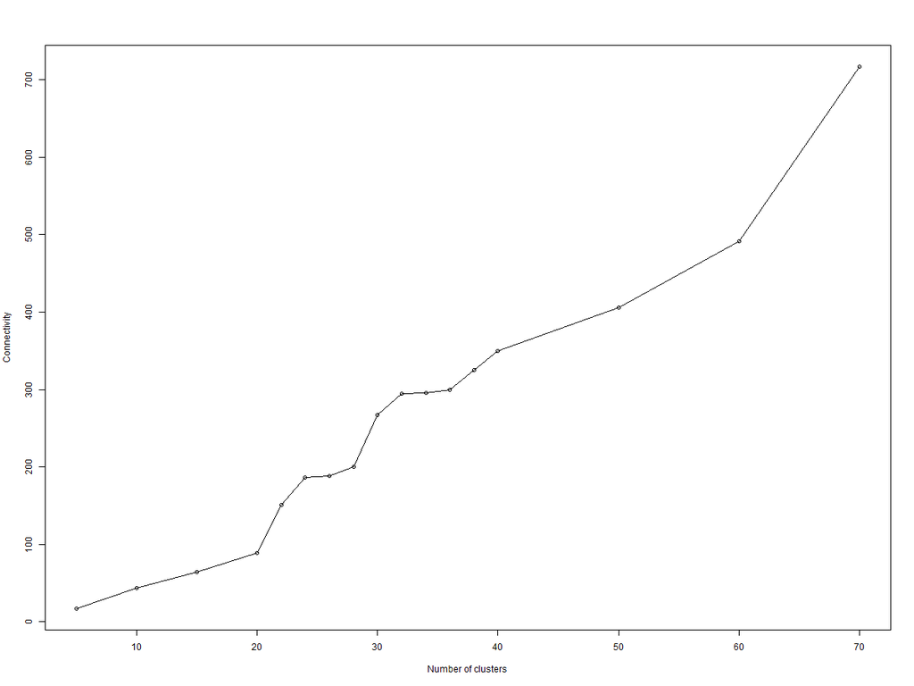

#### Internal measures: Dunn index (max)

File: meas_13111_2.png

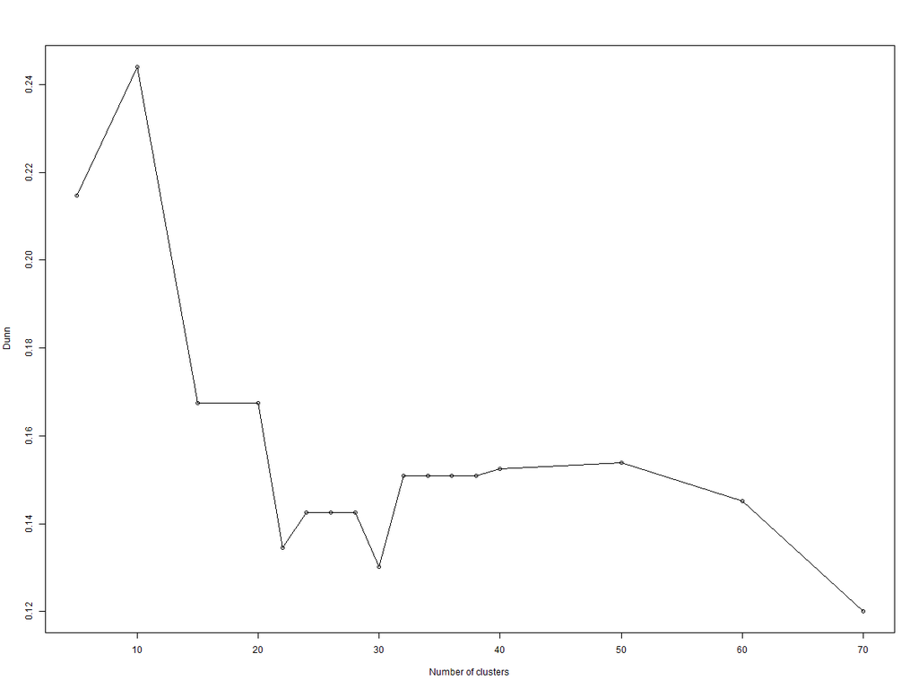

#### Internal measures: Silhouette (max)

File: meas_13111_3.png

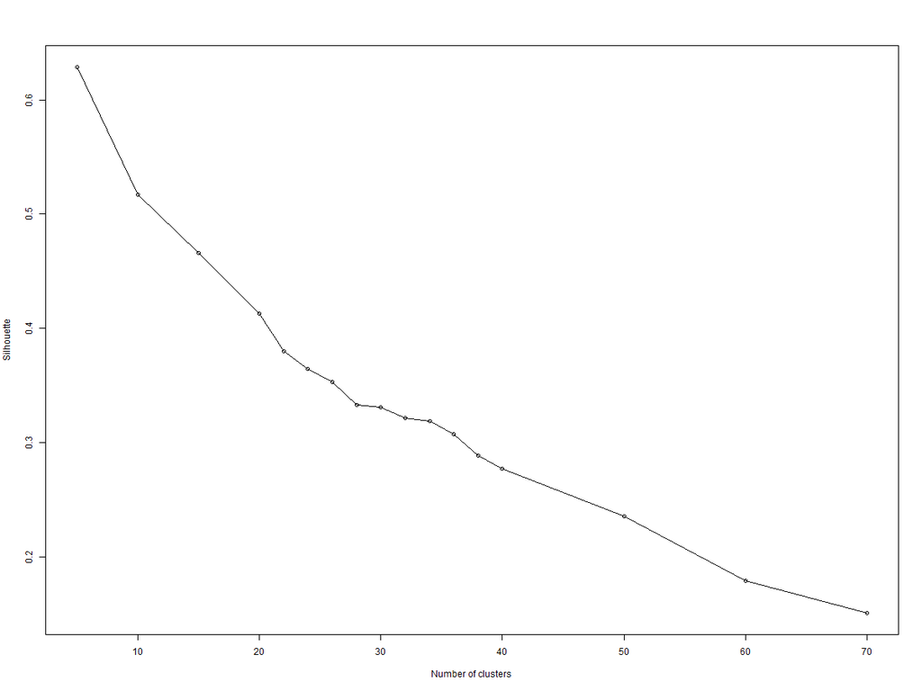

#### Stability measures: APN (min)

File: meas_13121_1.png

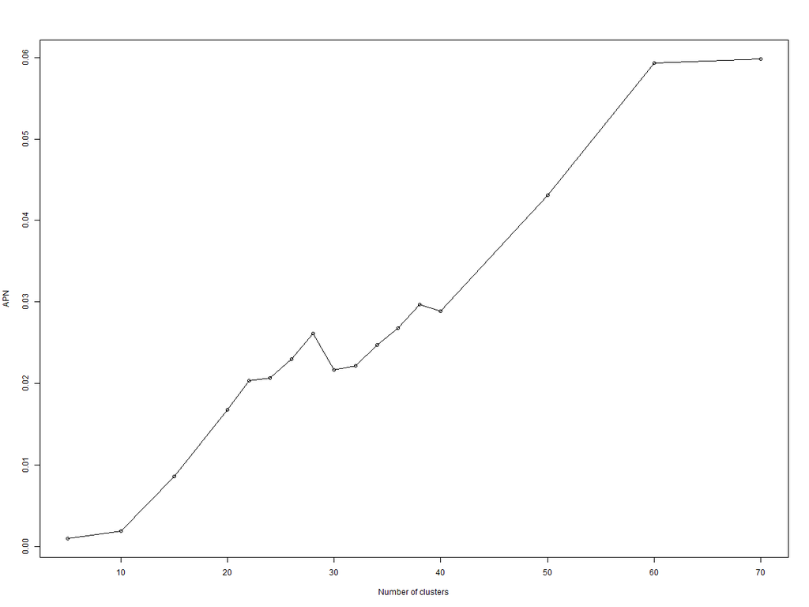

#### Stability measures: AD (min)

File: meas_13121_2.png

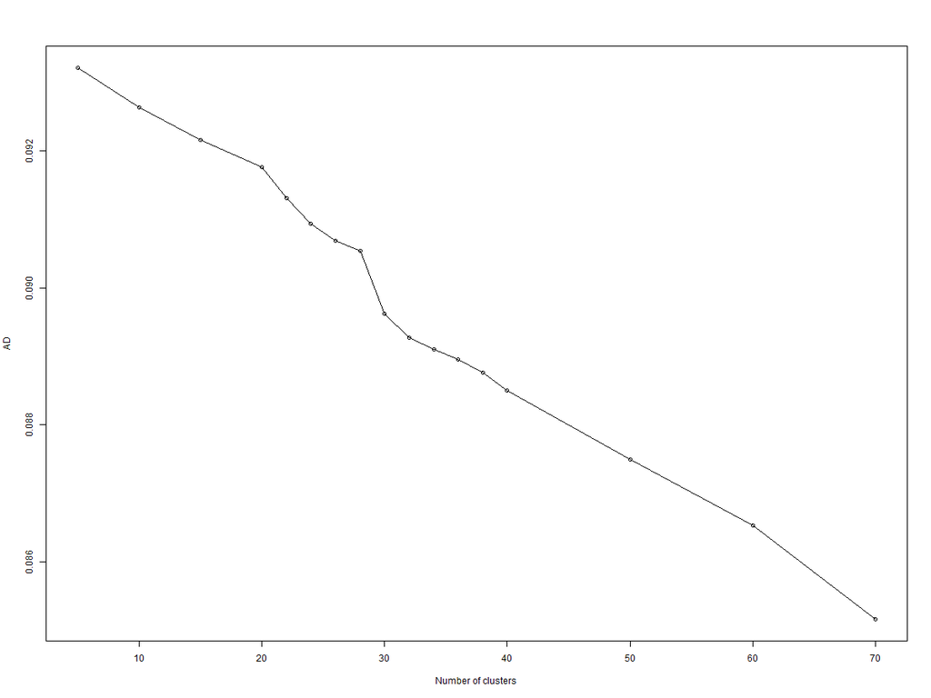

#### Stability measures: ADM (min)

File: meas_13121_3.png

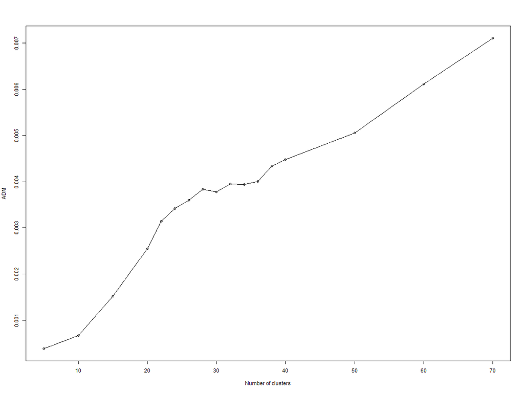

#### Stability measures: FOM (min)

File: meas_13121_4.png

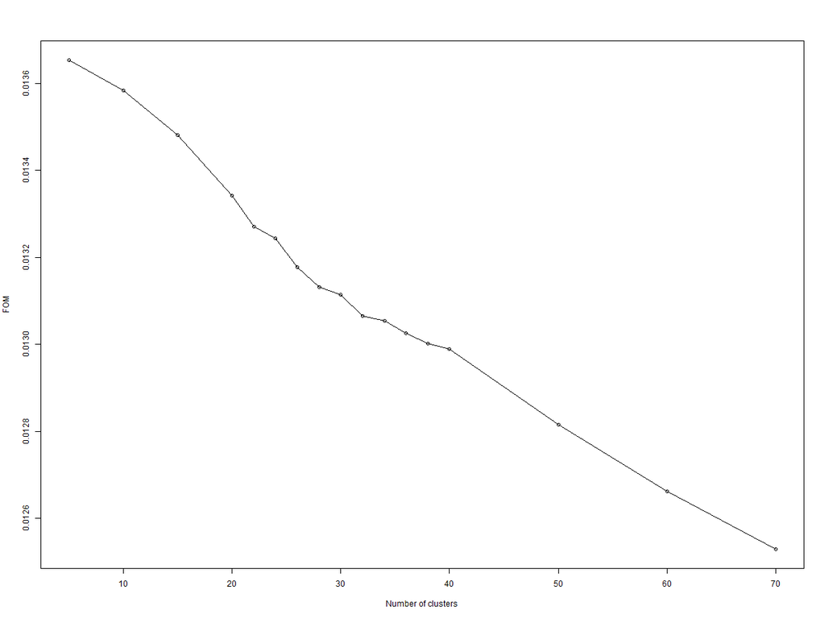

### Clustering: k-means

#### Internal measures: Connectivity (min)

File: meas_13211_1.png

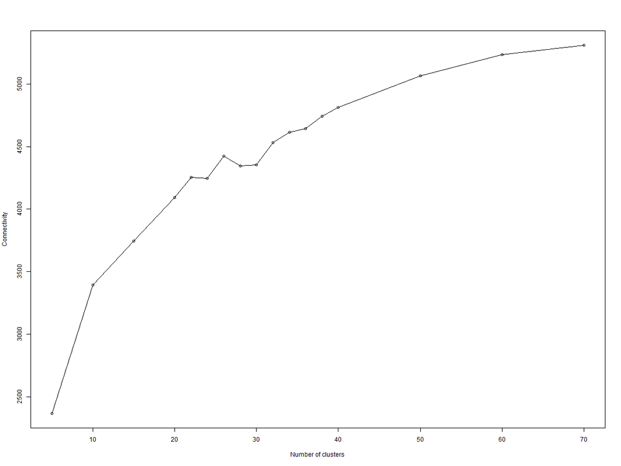

#### Internal measures: Dunn index (max)

File: meas_13211_2.png

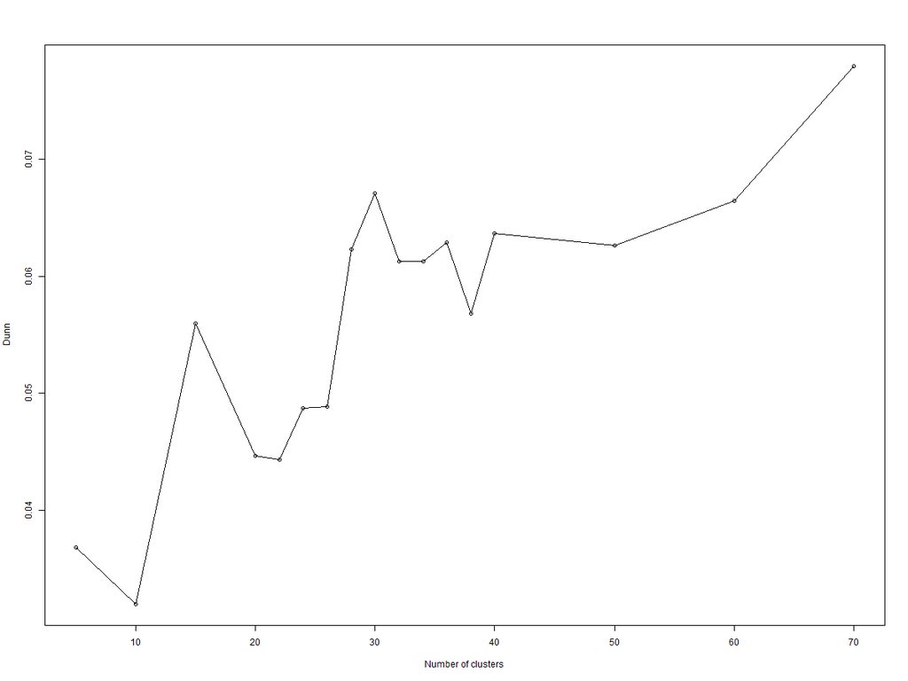

#### Internal measures: Silhouette (max)

File: meas_13211_3.png

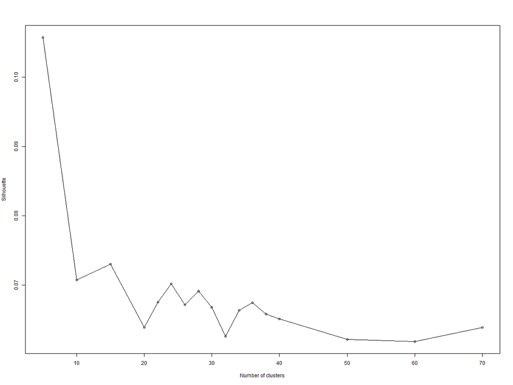

#### Stability measures: APN (min)

File: meas_13221_1.png

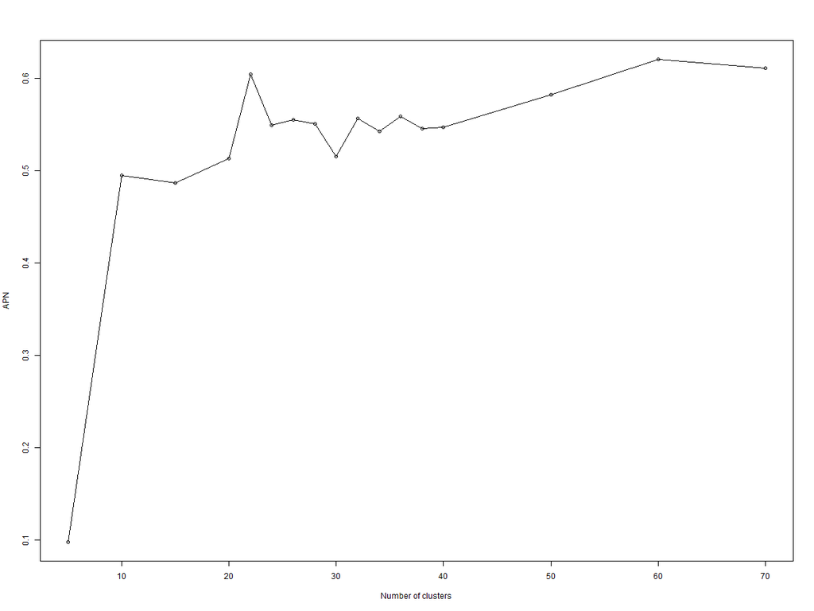

#### Stability measures: AD (min)

File: meas_13221_2.png

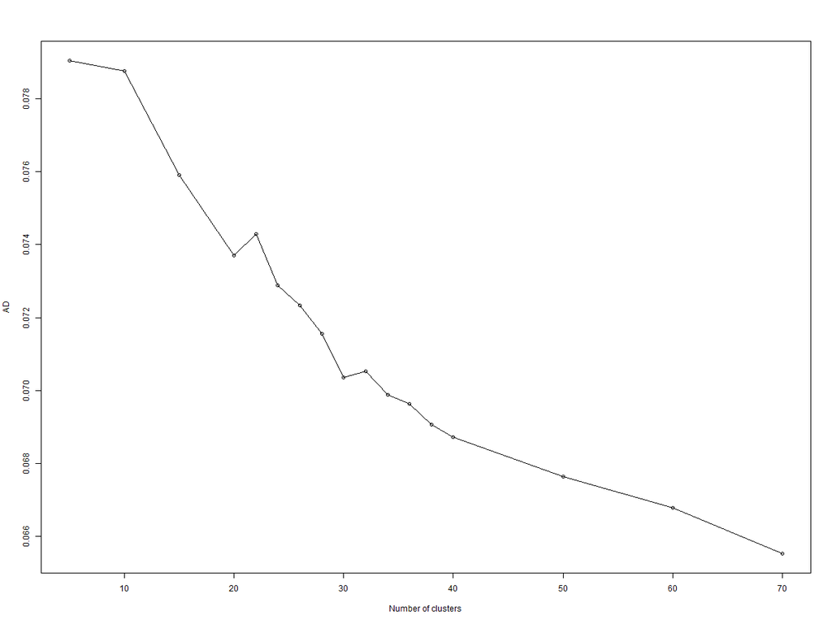

#### Stability measures: ADM (min)

File: meas_13221_3.png

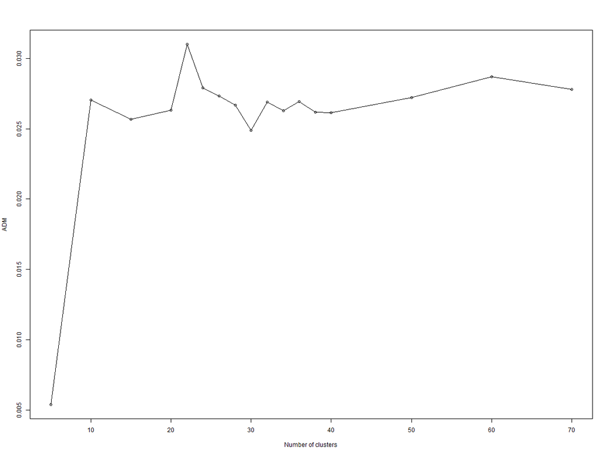

#### Stability measures: FOM (min)

File: meas_13221_4.png

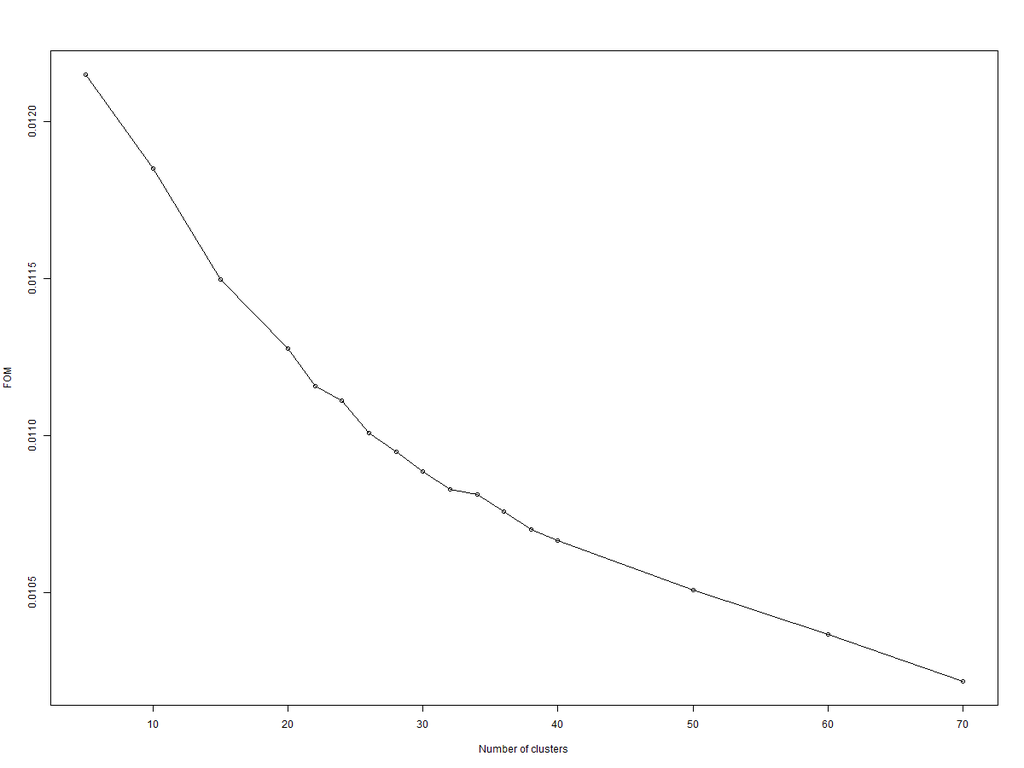

### Clustering: DIANA

#### Internal measures: Connectivity (min)

File: meas_13311_1.png

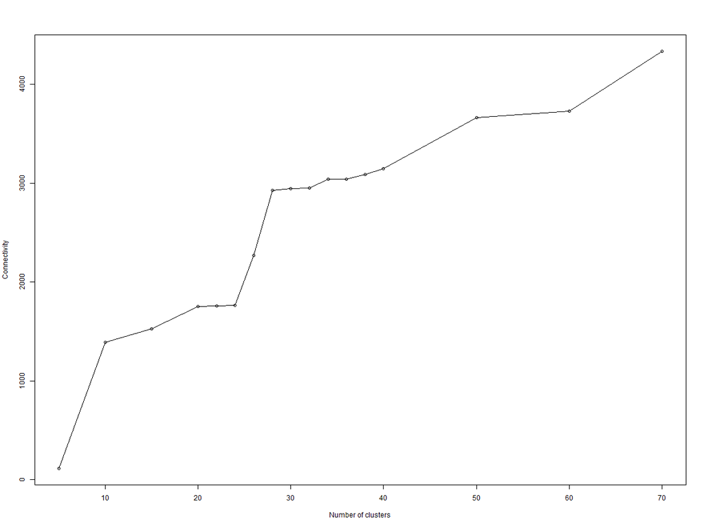

#### Internal measures: Dunn index (max)

File: meas_13311_2.png

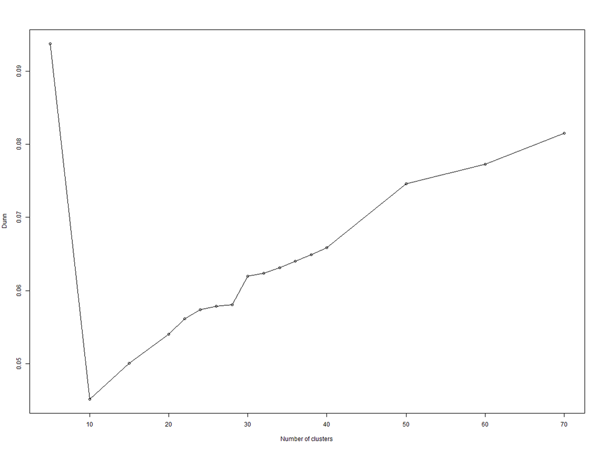

#### Internal measures: Silhouette (max)

File: meas_13311_3.png

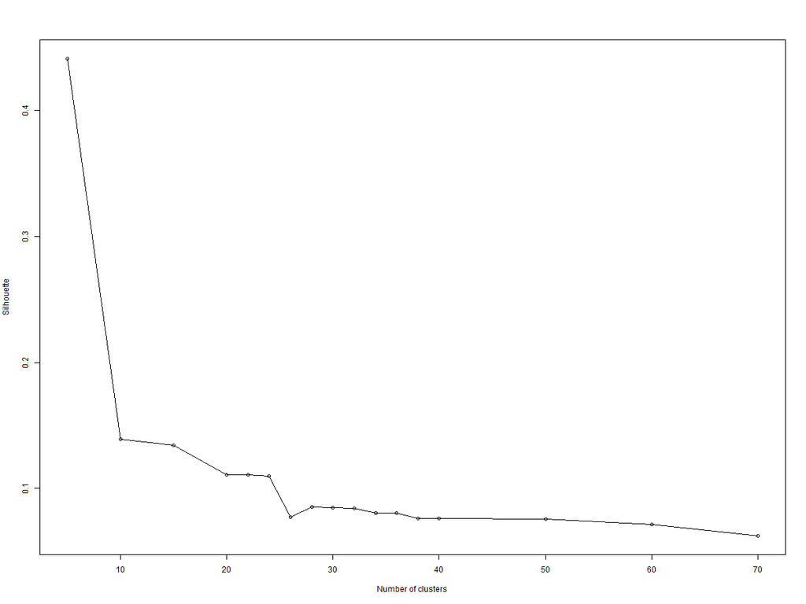

### Clustering: SOM

#### Internal measures: Connectivity (min)

File: meas_13511_1.png

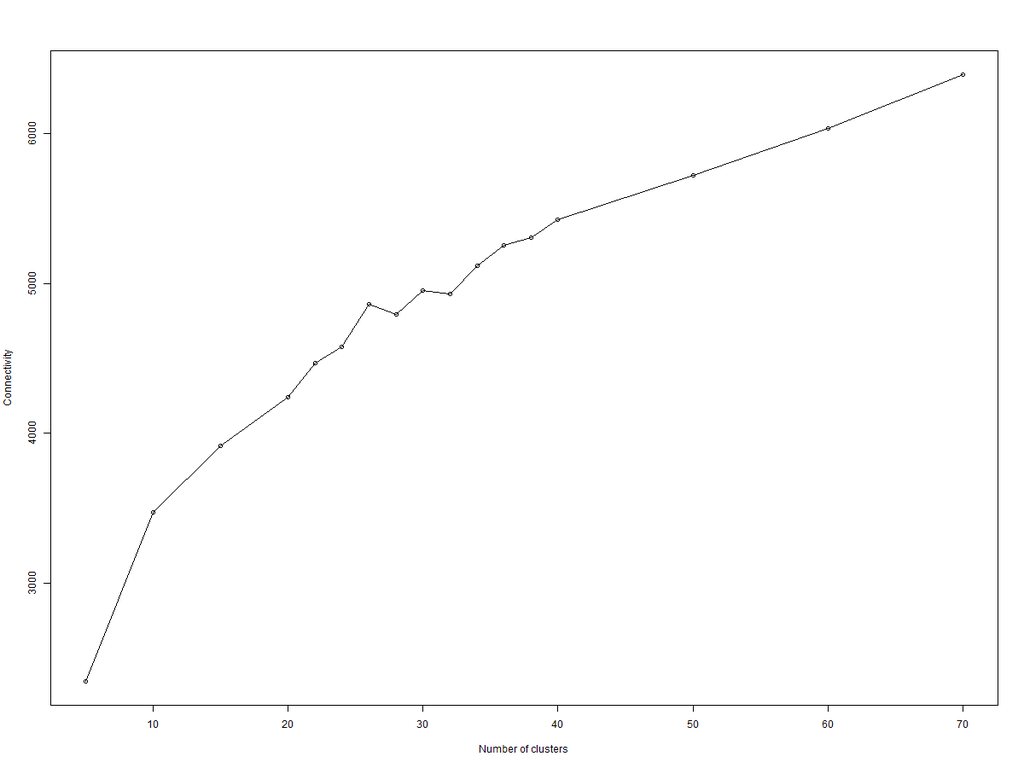

#### Internal measures: Dunn index (max)

File: meas_13511_2.png

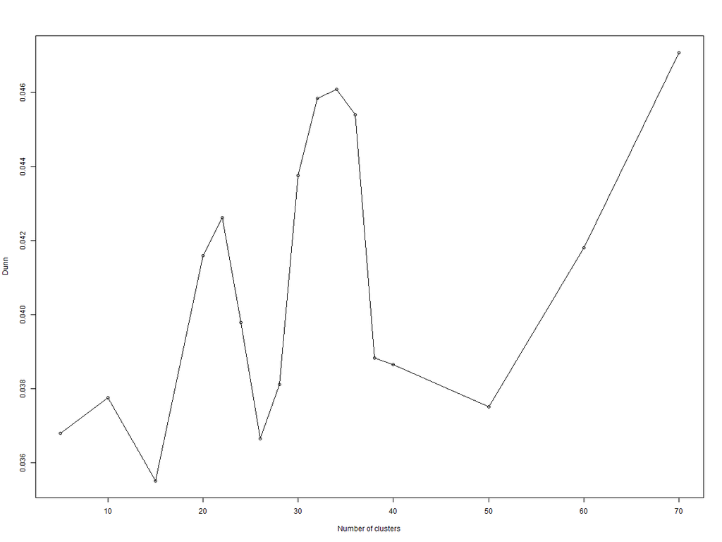

#### Internal measures: Silhouette (max)

File: meas_13511_3.png

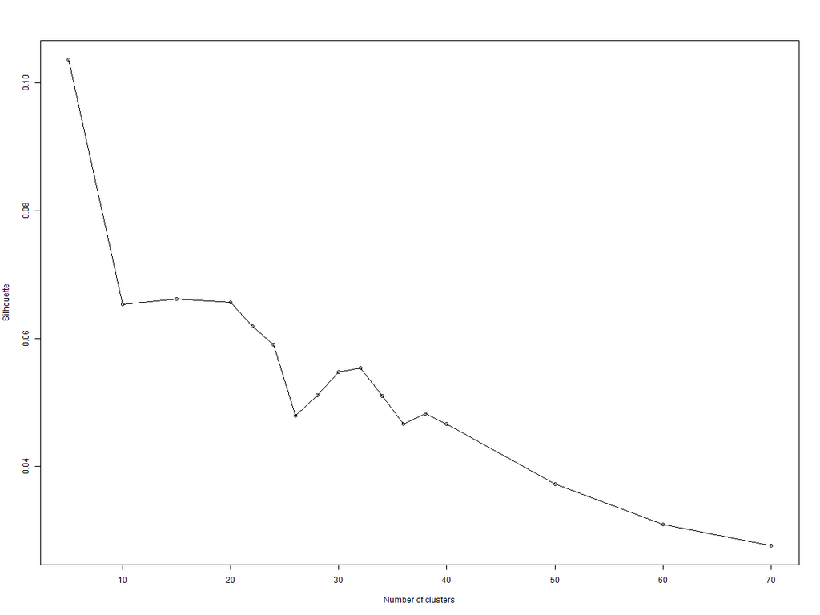

#### Stability measures: APN (min)

File: meas_13521_1.png

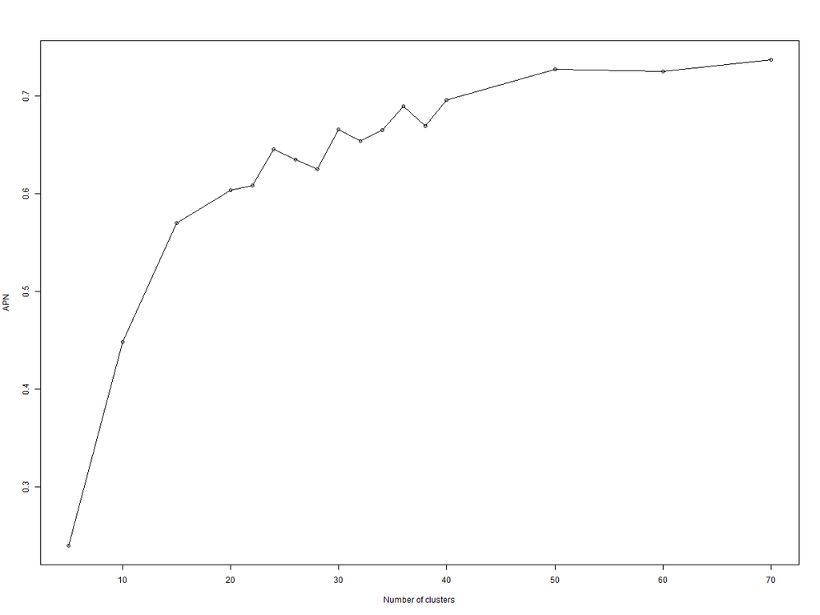

#### Stability measures: AD (min)

File: meas_13521_2.png

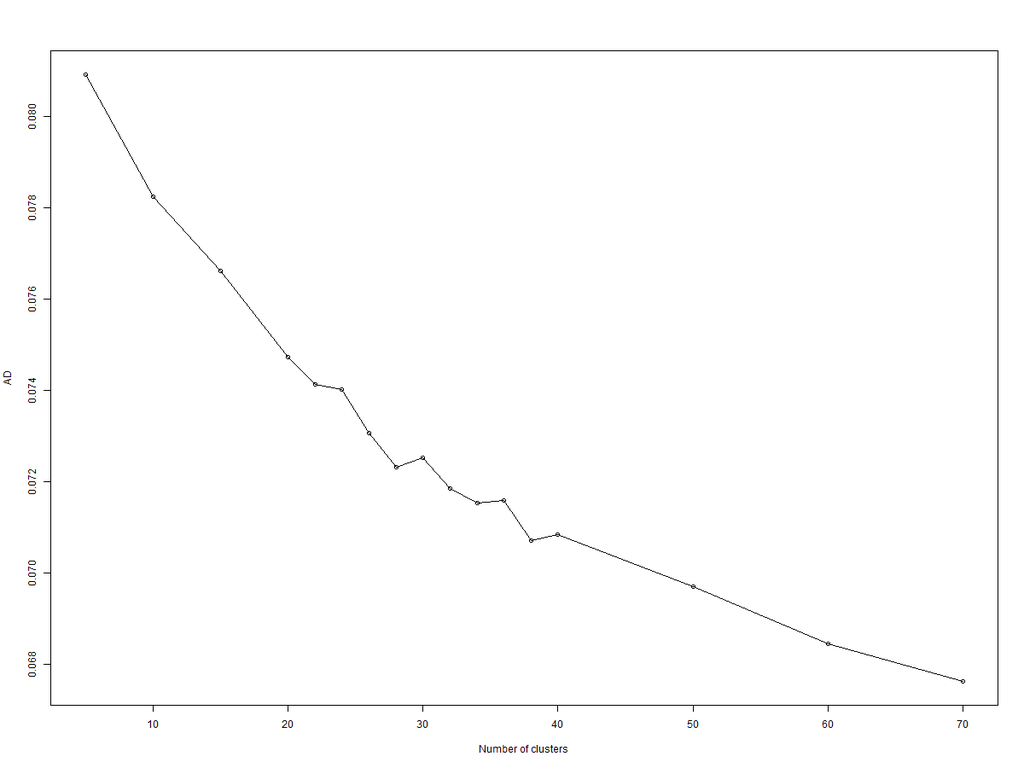

#### Stability measures: ADM (min)

File: meas_13521_3.png

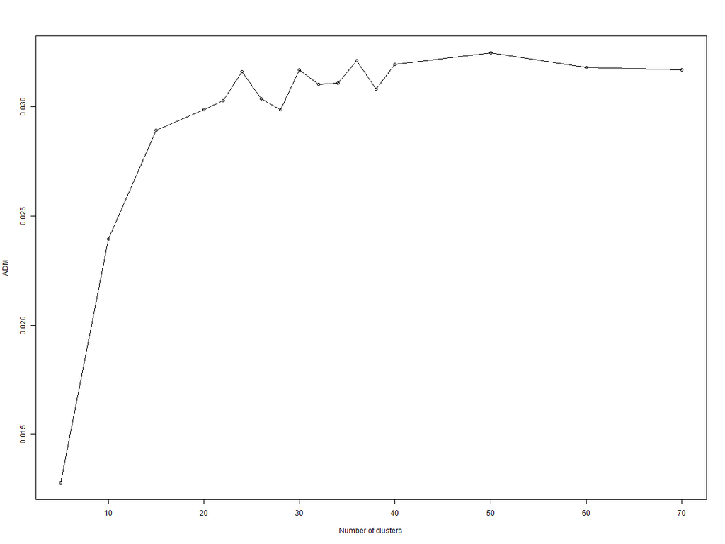

#### Stability measures: FOM (min)

File: meas_13521_4.png

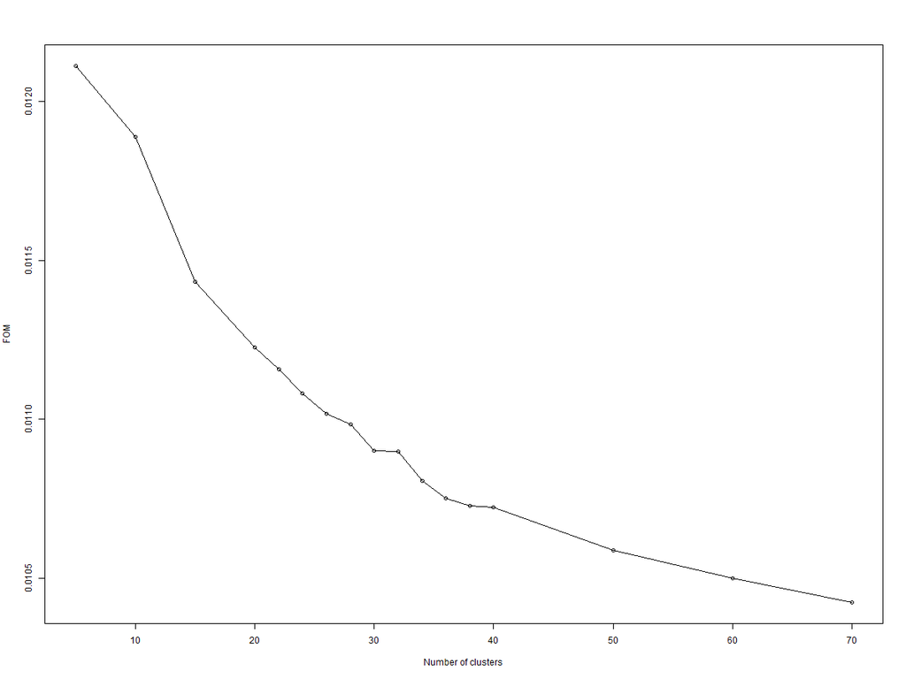

### Clustering: PAM

#### Internal measures: Connectivity (min)

File: meas_13611_1.png

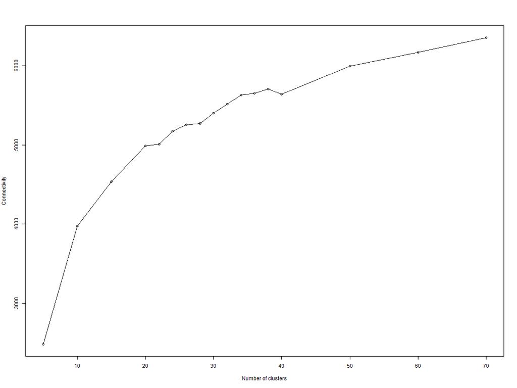

#### Internal measures: Dunn index (max)

File: meas_13611_2.png

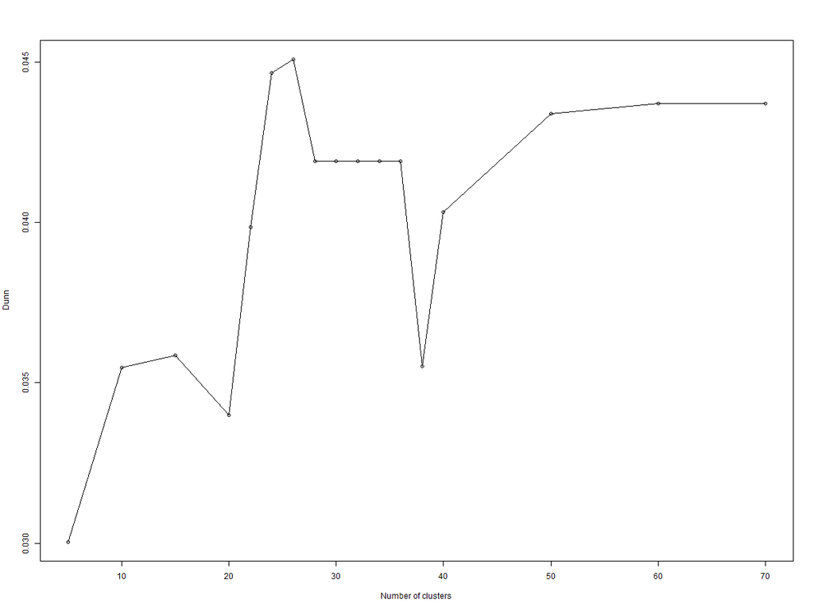

#### Internal measures: Silhouette (max)

File: meas_13611_3.png

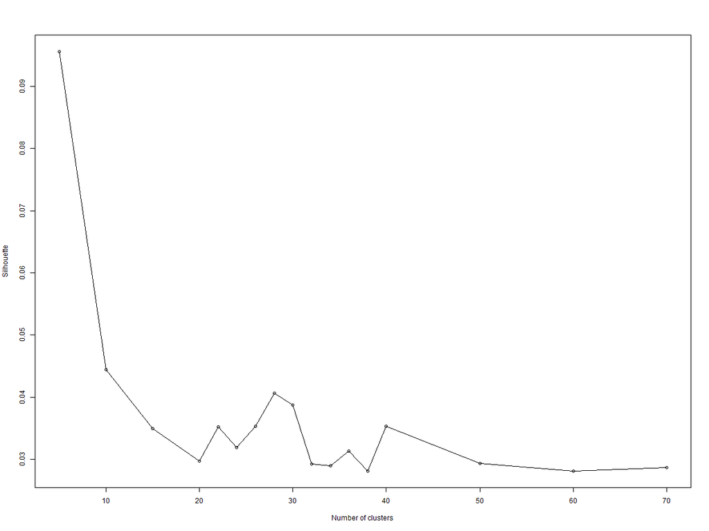

### Clustering: SOTA

#### Internal measures: Connectivity (min)

File: meas_13711_1.png

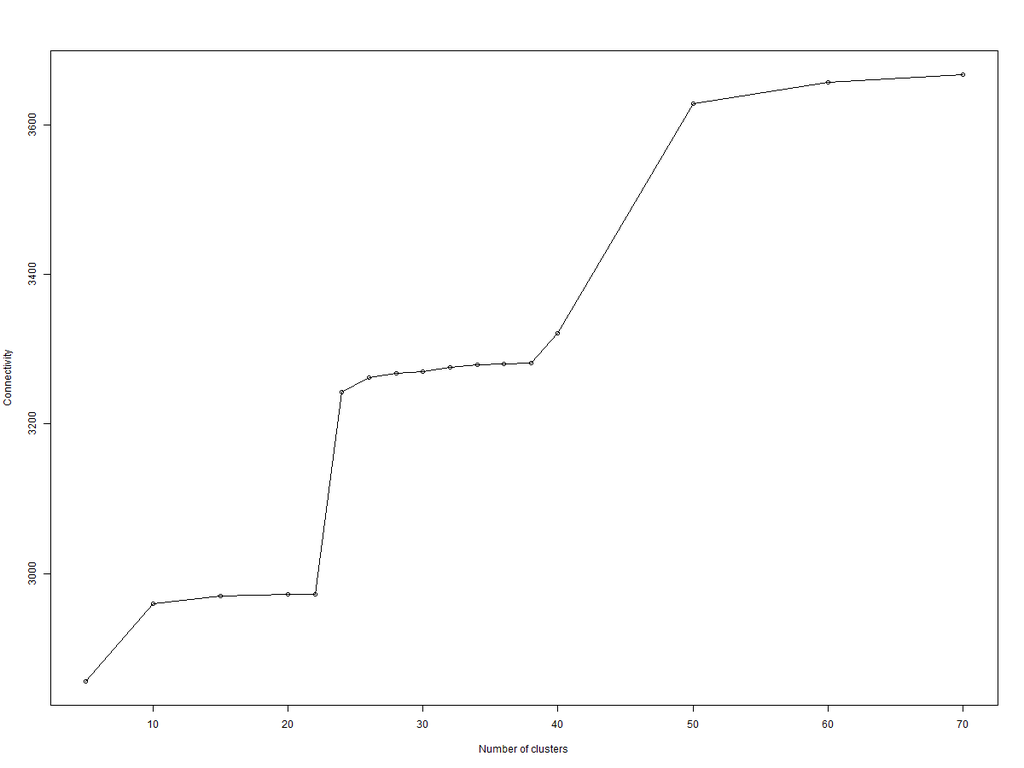

#### Internal measures: Dunn index (max)

File: meas_13711_2.png

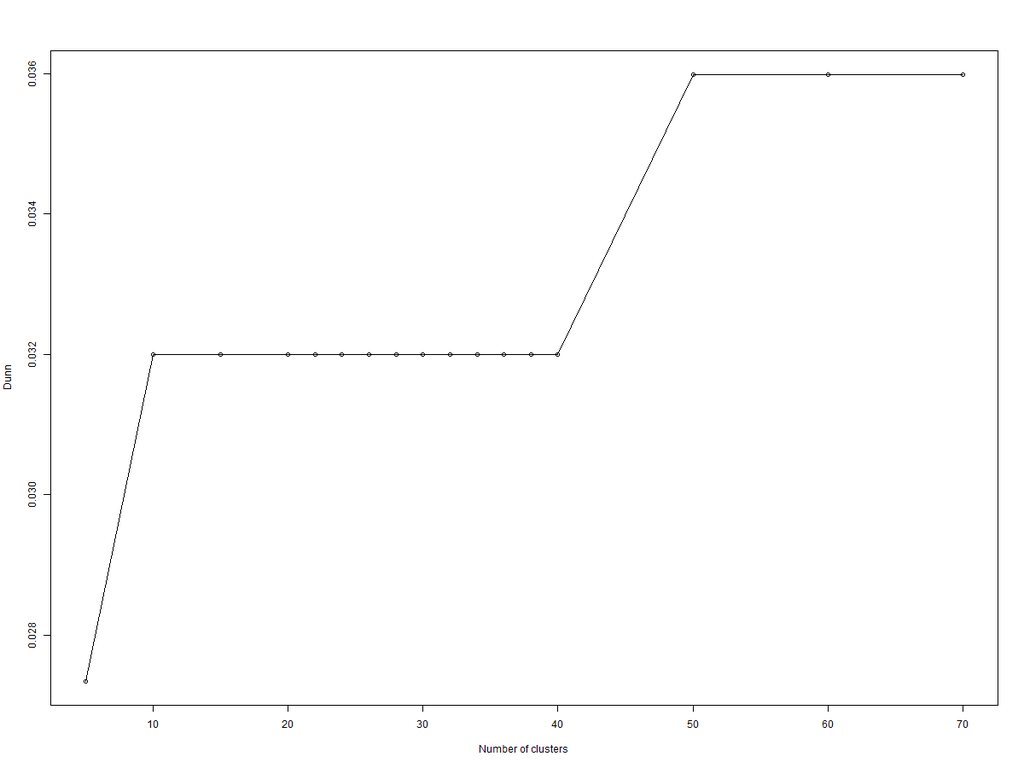

#### Internal measures: Silhouette (max)

File: meas_13711_3.png

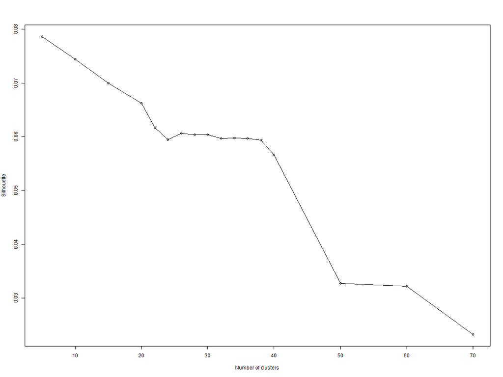

#### Stability measures: APN (min)

File: meas_13721_1.png

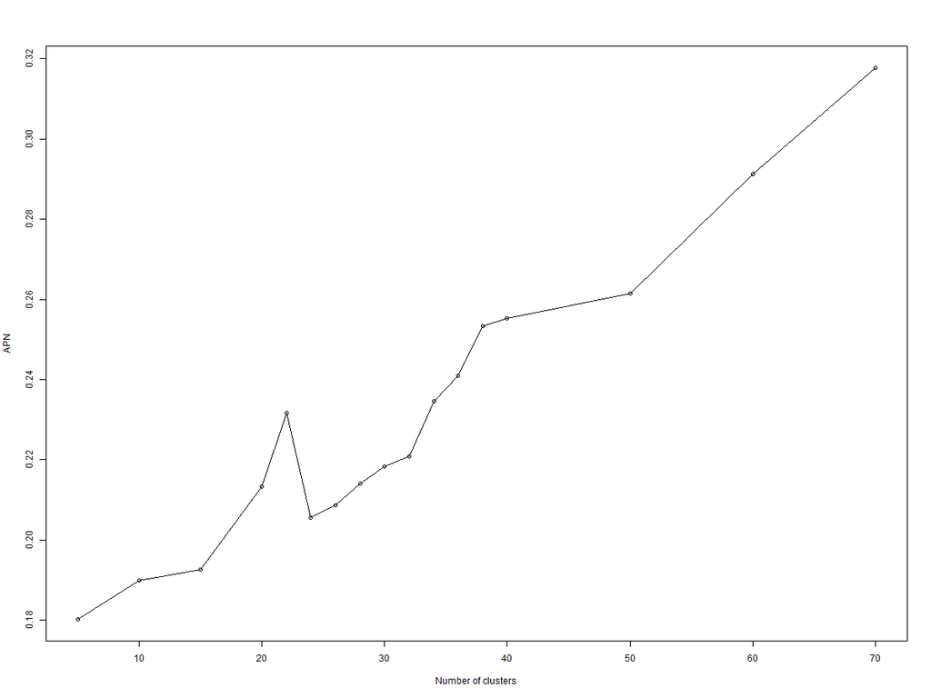

#### Stability measures: AD (min)

File: meas_13721_2.png

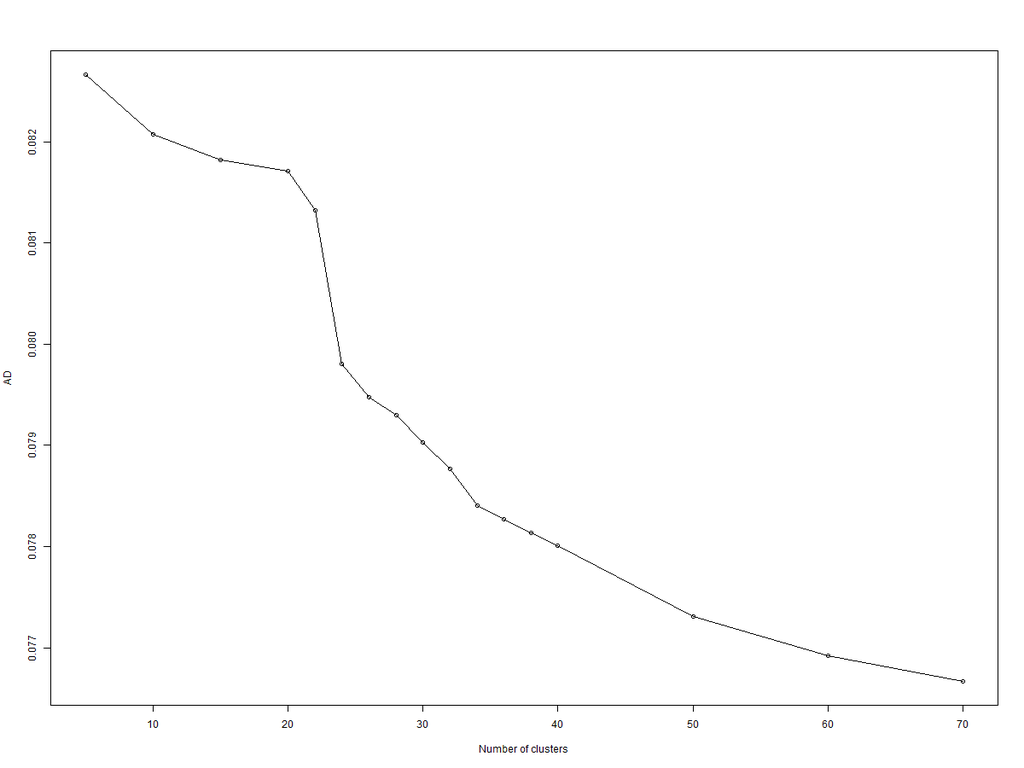

#### Stability measures: ADM (min)

File: meas_13721_3.png

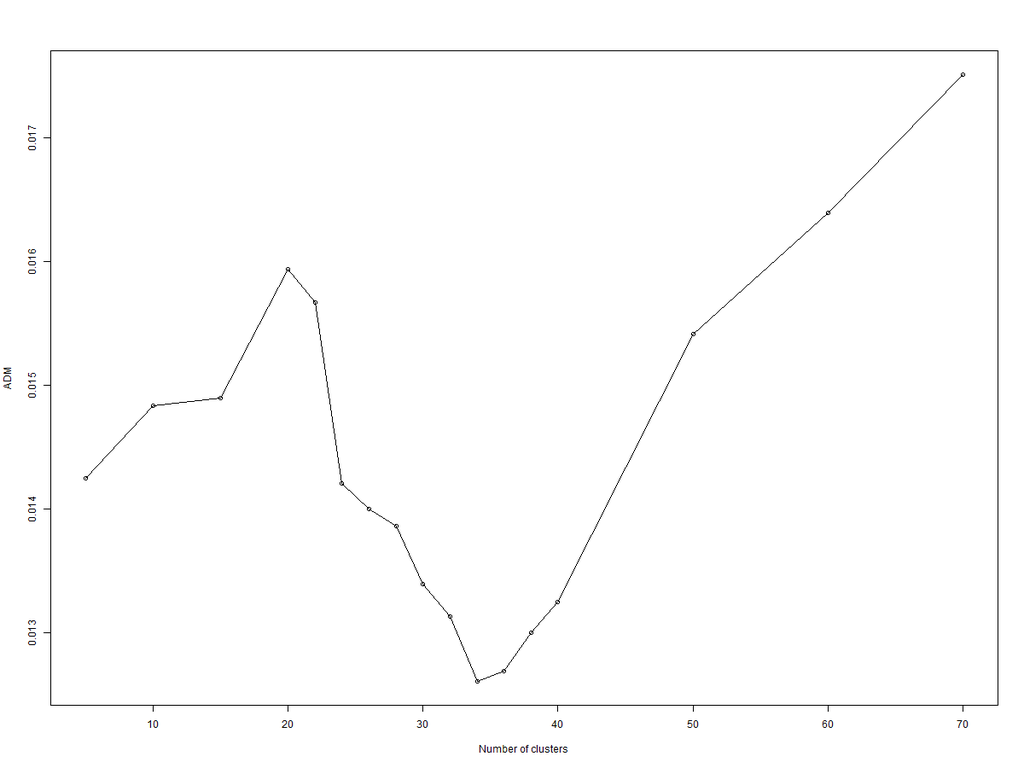

#### Stability measures: FOM (min)

File: meas_13721_4.png

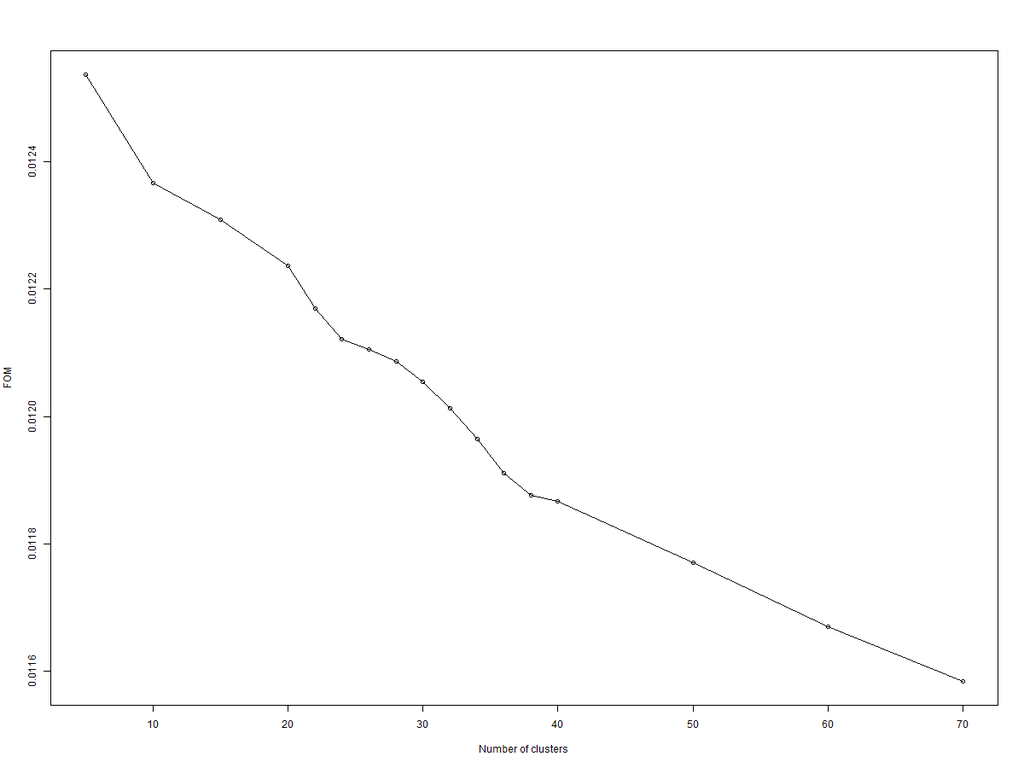

### Clustering: CLARA

#### Internal measures: Connectivity (min)

File: meas_13811_1.png

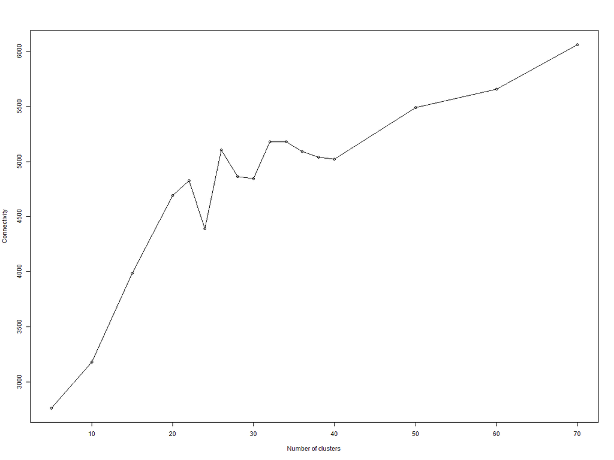

#### Internal measures: Dunn index (max)

File: meas_13811_2.png

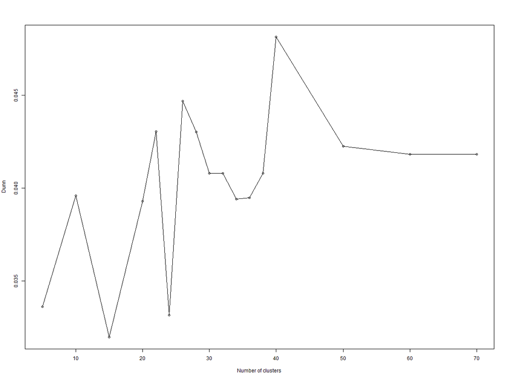

#### Internal measures: Silhouette (max)

File: meas_13811_3.png

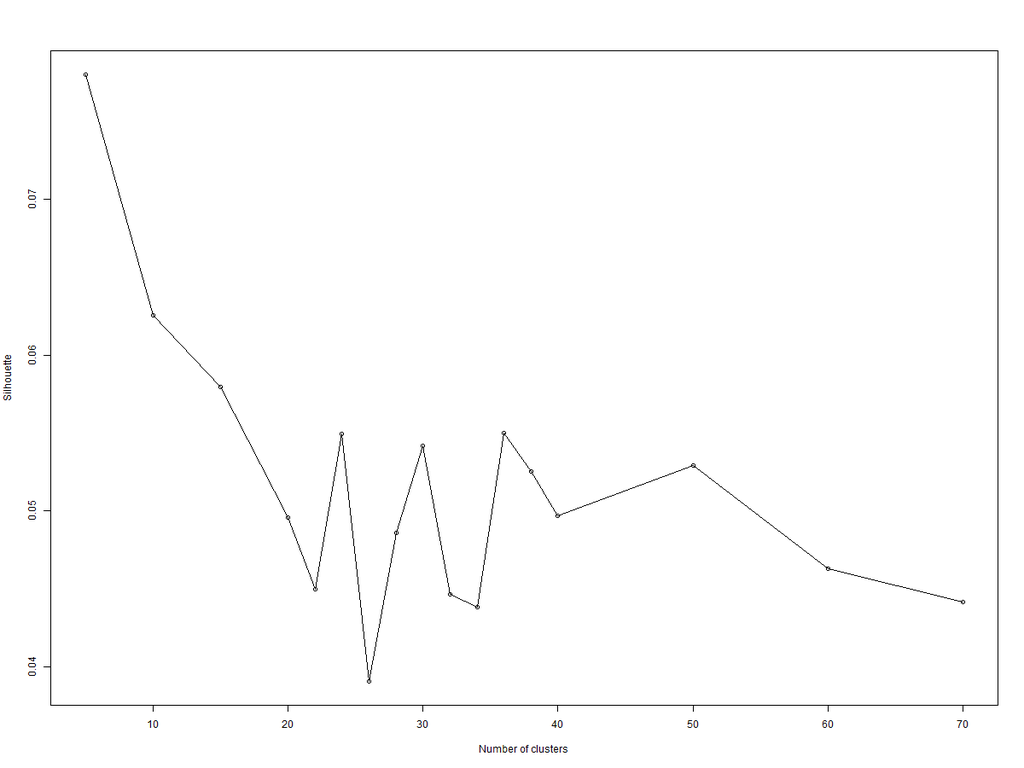

#### Stability measures: APN (min)

File: meas_13821_1.png

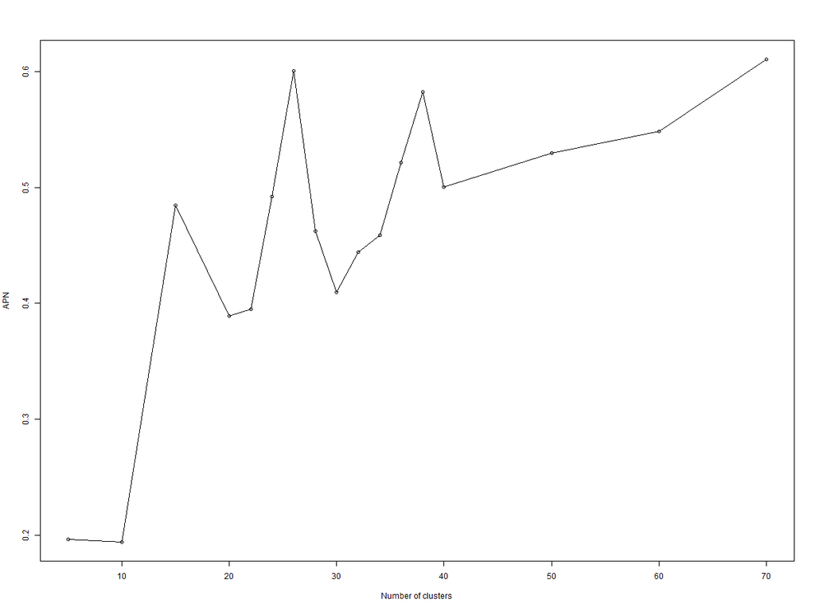

#### Stability measures: AD (min)

File: meas_13821_2.png

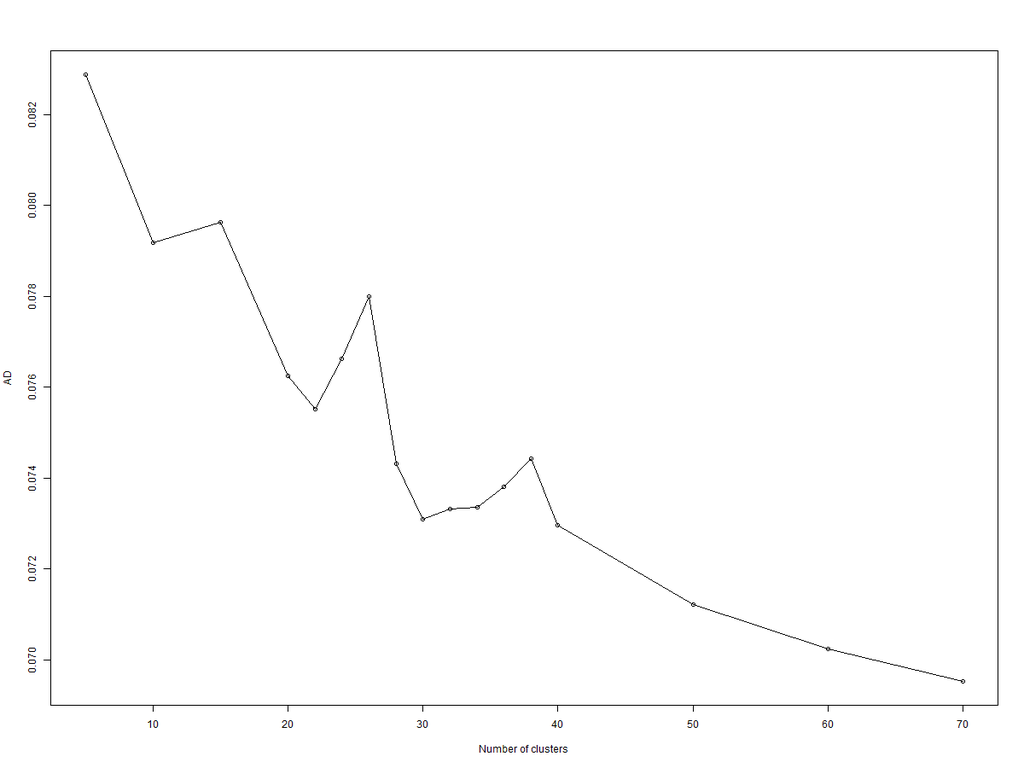

#### Stability measures: ADM (min)

File: meas_13821_3.png

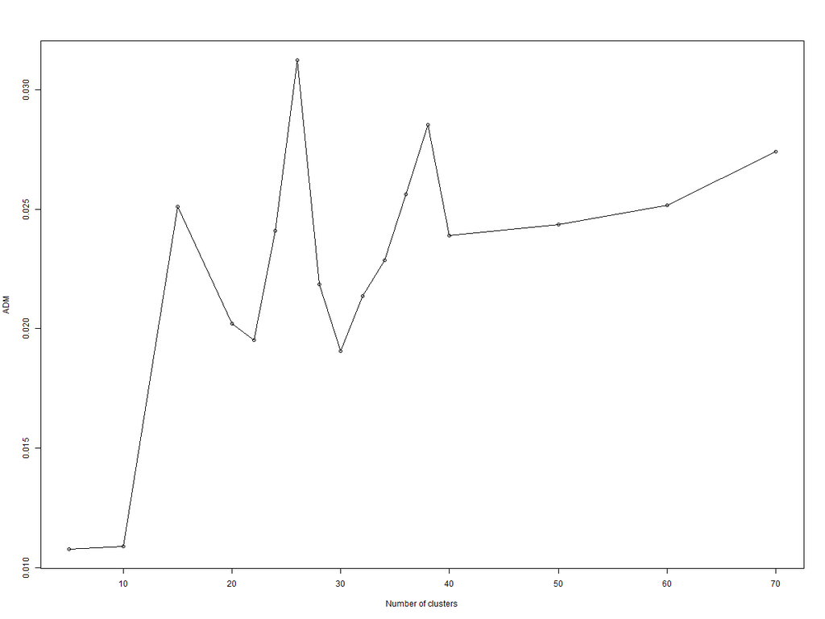